# Bivariate and Multivariate OLS

Session 2, GV481

[GV481 Homepage](https://kevinli03.github.io/notes/#GV481_Quantitative_Analysis)

Week 1, Quantitative Analysis for Political Science

- Title: Bivariate and Multivariate OLS
- Topics: Simple Linear Regression, Multivariate Linear Regression
- Readings:
  1. Chapters 4 and 5, Mesquita et al (2021) *Thinking Clearly with Data: A Guide to Quantitative Reasoning and Analysis*
  2. Chapters 2.1-2.14, Cunningham, S. (2021) *Causal Inference: The Mixtape*
  3. Fowler, A. (2018) ‘Do Shark Attacks Influence Presidential Elections’, *The Journal of Politics*, 80(4), pp. 1423-1437
  4. Suryanarayan, P. and Steven, W. (2021) ‘Slavery, Reconstruction, and Bureaucratic Capacity in the American South’, *The American Political Science Review*, 155(2), pp. 568-584
  5. Haber, S. and Victor, M. (2011) ‘Do Natural Resources Fuel Authoritarianism? A Reappraisal of the Resource Curse’, *The American Political Science Review*, 105(1), pp. 1-26.

[GV481 Homepage](https://kevinli03.github.io/notes/#GV481_Quantitative_Analysis)

# Key Points

The **best linear predictor** is the function $Y = \alpha + \beta X$ that best predicts $Y$.

- Where $\alpha$ and $\beta$ are parameters we estimate from a dataset of values

In our model $\hat{Y} = \alpha + \beta X$, the **interpretation** is as follows

- coefficient $\alpha$ is the predicted $Y$ when $X=0$
- Coefficient $\beta$ is the predicted change in $Y$ given a one unit increase of $X$
- You will need to know how $Y$ and $X$ are measured to make this meaningful.

If one of the measurements is not very meaningful (ex. a 0-100 scale of democracy), we can also do another **interpretation in terms of standard deviation**

**Properties of the OLS Model**:

- All the residuals should add up to 0. Mathematically: $\sum[y_i-(\hat{\beta}_0 + \hat{\beta}_1 x_i)] = 0$
- We can predict the sample mean of $y$ as follows: $\bar{y} = \hat{\beta}_0 + \hat{\beta}_1 \bar{x}$

**Multivariate models** take the following form:

$$Y = \alpha + \beta_1 X_1 + \beta_2 X_2 + ... + \beta_nX_n +\epsilon$$

Now, $\beta_1$ represents the expected change of $Y$ given a one unit of $X_1$, given other variables $X_2, X_3, ...$ are held constant

The $\beta_1$ has a different estimation formula:

$$\hat{\beta_1} = \frac{ \sum \hat{r}_{i1} y_i}{ \sum \hat{r}_{i1}^2}$$

Where $\hat{r}_{i1}$ are the residuals obtained from regressing $X_1$ on $X_2$. This gives the part of $X_1$ that is uncorrelated with $X_2$

To deal with a non-linear relationship, we can use a **polynomial transformation**.

$$\hat{Y} = \alpha + \beta_1 X + \beta_2 X^2 ...$$

- If we want higher degree transformation, we can add another term
- Higher polynomials may fit the data better, but may overfit, and be hard to interpret

**Overfitting** essentially means that within our training data, the model performs amazingly, but with new data on $X$ to predict $Y$, it performs poorly

- This is because it is fit too closely to our training data, which means it is only good at predicting the existing data, not new data
- Remember, our training data is just a sample from a population. New data drawn from the population will not be exactly the same. We are interested in predicting $Y$ of the population, not of our specific training sample

In data science, we can avoid overfitting through either making training/testing sets, or cross-validation

[GV481 Homepage](https://kevinli03.github.io/notes/#GV481_Quantitative_Analysis)

# OLS Regression

### Background

The best linear predictor is the function $Y = \alpha + \beta X$ that best predicts $Y$.

- This takes the form of a linear line - a straight line
- This should give us our best guess for $Y$, given a value of $X$

How do we choose this line, specifically the coefficient $\beta$ ?

- We choose the line that minimises the sum of the squared prediction errors
- A squared prediction error is the difference between the actual $y$ value at a point, and its estimate $\hat{y}$, then squared
  - I.e. $(y - \hat{y})^2$
- Then, we sum up all these squared errors: $\sum (y - \hat{y})^2$
- We choose the line that minimises this value

The coefficient $\beta$ tells us the following:

- The sign of beta tells us the direction of relationship (positive or negative)
- $\beta$ itself represents the expected change in $Y$, given an increase of one unit of $X$

### OLS Estimator

Of course, drawing every possible linear line, and measuring the sum of squared errors, is very inefficient.

One way to estimate this with much less effort but strong accuracy is the ordinary least squares estimator. The procedure is as follows:

1. Sample units from the population, and collect data on both $X$ and $Y$ for each individual in the sample
2. Find $\alpha$ and $\beta$ that minimise the sum of squared errors

The formula for the $\beta$ in OLS is as follows:

$$\hat{\beta} = \frac{\sum (y_i - \bar{y}) (x_i - \bar{x}) }{\sum (x_i -
x)^2}$$

### Application: Resource Curse

Question: are oil-rich countries less likely to be democratic, than non-oil countries?

- Or in other words, is there a correlation between large oil revenues, and democracy

Our equation is as follows: Democracy $= \alpha + \beta_1$Fiscal Reliance $+ \epsilon$

- The sign of $\beta_1$ tells us the direction of the relationship between the two variables

Remember: $X$ is our explanatory variable, $Y$ is the outcome variable

### Interpretation of OLS Model

Haber and Menaldo (2011) collected data for some countries on regime type and oil reliance.

To implement in R, you do the following:

```r
model <- lm(democracy ~ fiscalreliance, data = mydata)
```

The output is as follows:

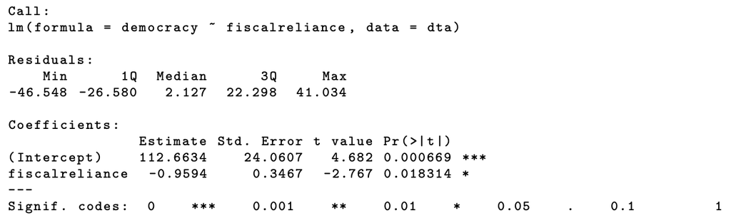

This tells us that for every one unit increase of fiscal reliance, democracy decreases by -0.9594.

- But what does this actually mean? We need to know how fiscal reliance and democracy is measured
- Fiscal reliance is measured between 0 and 100 percent. Democracy is measured between 0 and 100, where 100 means more democracy

That means, a 1 percentage point increase in fiscal reliance on oil, there is a -0.9594 predicted change in democracy.

It is still hard to understand what this means in terms of democracy - since it is such an arbitrary scale

- So instead, we often use standard deviation change
- Why? if we have normally distributed variables, we know that 2/3 of the distribution is within one standard deviation. 2 standard deviations should cover 95% of the distribution of the variable.
- Thus, we can use standard deviation to see how drastic the change is, in respect to the variable

How do we get $Y$ in respect to 1 standard deviation increase of $X$?

- $Y$ changes by $(SD_X \times \beta_1)/SD_Y$

- Generally anything above a 1/3 standard deviation change is considered a big change.

$\beta_0$ gives us the predicted value of $Y$, when $X=0$

- So in this case, when fiscal reliance is 0, the expected value of democracy is 112.6634 (obviously, this doesn’t make much sense)
- As a product of OLS, sometimes, $\beta_0$ may not make much sense in terms of contextual interpretation

### Binary Y Variable

Generally, you should use a logistic model for binary $Y$. But, it is still possible in linear regression.

Interpretation of the coefficients is still mostly the same, with a slight changes:

- $\alpha$ tells us the predicted probability of $Y=1$, when $X = 0$
- $\beta$ is now the predicted change in the probability of event $Y=1$, given one unit increase of $X$
- Once again, we can do the expected standard deviation change in $Y$, given one standard deviation increase in $X$

[GV481 Homepage](https://kevinli03.github.io/notes/#GV481_Quantitative_Analysis)